# hw7

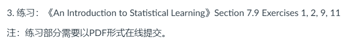

1，

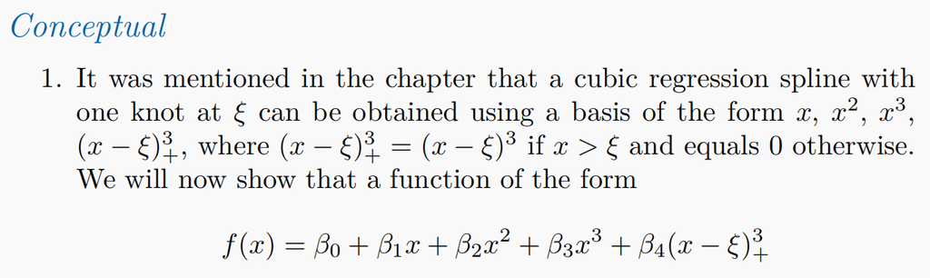

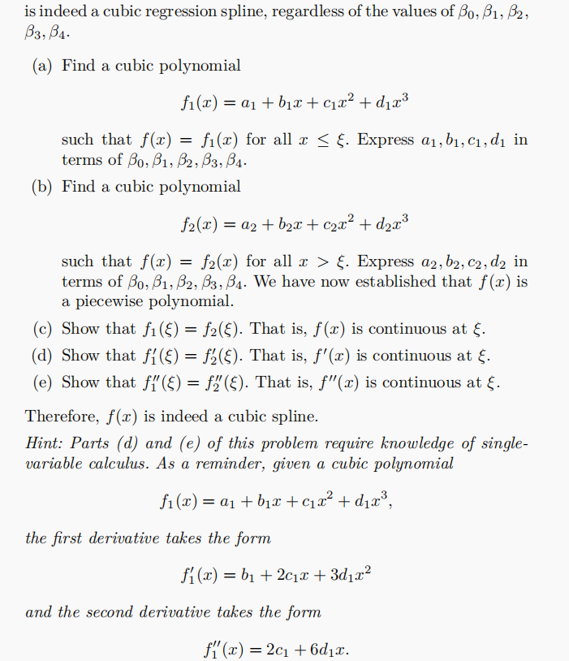

a,

for $x \le \xi$,

$a_1 = \beta_0$, $b_1 = \beta_1$, $c_1 = \beta_2$, $d_1 = \beta_3$

b,

For $x \gt \xi$, \begin{align} f(x) = & \beta_0 + \beta_1x + \beta_2x^2 + \beta_3x^3 + \beta_4(x-\xi)^3 \\ = & \beta_0 + \beta_1x + \beta_2x^2 + + \beta_4(x^3 - 3x^2\xi + 3x\xi^2 -\xi^3) \\ = & \beta_0 - \beta_4\xi^3 + (\beta_1 + 3\beta_4\xi^2)x + (\beta_2 - 3\beta_4\xi)x^2 + (\beta_3 + \beta_4)x^3 \end{align}

所以, $a_1 = \beta_0 - \beta_4\xi^3$, $b_1 = \beta_1 + 3\beta_4\xi^2$, $c_1 = \beta_2 - 3\beta_4\xi$, $d_1 = \beta_3 + \beta_4$

c，

对照2，将 $x$ 替换 $\xi$

\begin{align} f_1(\xi) = \beta_0 + \beta_1\xi + \beta_2\xi^2 + \beta_3\xi^3 \end{align}

\begin{align} f_2(\xi) = & \beta_0 - \beta_4\xi^3 + (\beta_1 + 3\beta_4\xi^2)\xi + (\beta_2 - 3\beta_4\xi)\xi^2 + (\beta_3 + \beta_4)\xi^3 \\ = & \beta_0 - \beta_4\xi^3 + \beta_1\xi + 3\beta_4\xi^3 + \beta_2\xi^2 - 3\beta_4\xi^3 + \beta_3\xi^3 + \beta_4\xi^3 \\ = & \beta_0 + \beta_1\xi + \beta_2\xi^2 + \beta_3\xi^3 \end{align}

d，

$$ f_1'(x) = \beta_1 + 2\beta_2x + 3\beta_3x^2 f_1'(\xi) = \beta_1 + 2\beta_2\xi + 3\beta_3\xi^2 $$

\begin{align} f_2'(x) & = \beta_1 + 3\beta_4\xi^2 + 2(\beta_2 - 3\beta_4\xi)x + 3(\beta_3 + \beta_4)x^2 \\ f_2'(\xi) & = \beta_1 + 3\beta_4\xi^2 + 2(\beta_2 - 3\beta_4\xi)\xi + 3(\beta_3 + \beta_4)\xi^2 \\ & = \beta_1 + 3\beta_4\xi^2 + 2\beta_2\xi - 6\beta_4\xi^2 + 3\beta_3\xi^2 + 3\beta_4\xi^2 \\ & = \beta_1 + 2\beta_2\xi + 3\beta_3\xi^2 \end{align}

e,

$$ f_2''(x) = 2\beta_2 - 6\beta_4\xi + 6(\beta_3 + \beta_4)x \\ $$

\begin{align} f_2''(\xi) & = 2\beta_2 - 6\beta_4\xi + 6\beta_3\xi + 6\beta_4\xi \\ & = 2\beta_2 + 6\beta_3\xi \end{align}

2，

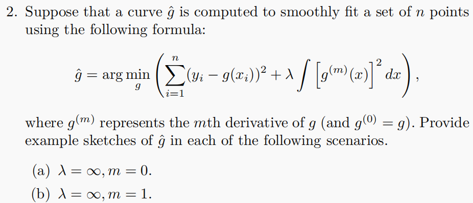

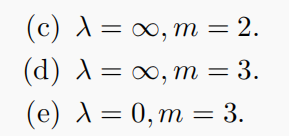

a,

对$g$做惩罚项，无穷大的$\lambda$意味着这个惩罚占主导地位。这意味着$\hat{g}$等于0。

b,

这里我们惩罚$g$的一阶导数（斜率）,无穷大的$\ λ $意味着这个惩罚占主导地位。因此斜率将为0

c,

这里我们惩罚$g$的二阶导数（斜率的变化）,一个无穷大的$\ λ $意味着这个惩罚占主导地位。因此这条线将是直的

d,

这里我们惩罚了g的三阶导数（斜率的变化量）,无穷意味着这个惩罚占主导地位。换句话说，曲线将具有一致的变化率（例如二次函数等）。

e,

这里我们对三阶导数进行惩罚，但是值$\ λ = 0$意味着没有惩罚。因此，该曲线能够插值所有点。

9,

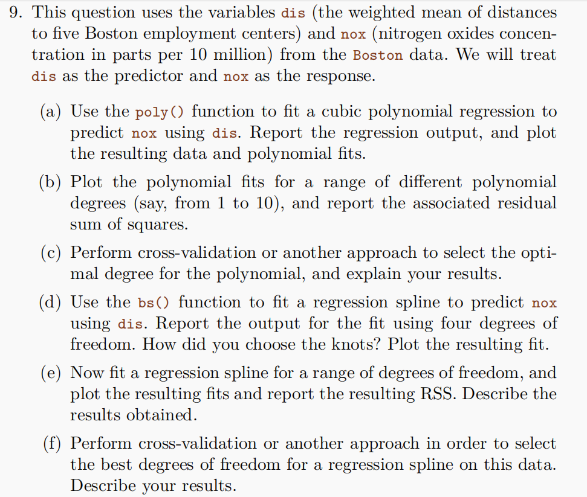

```r
library(MASS)
```

```
Call:
glm(formula = nox ~ poly(dis, 3), data = Boston)

Coefficients:
               Estimate Std. Error t value Pr(>|t|)
(Intercept)    0.554695   0.002759 201.021  < 2e-16 ***
poly(dis, 3)1 -2.003096   0.062071 -32.271  < 2e-16 ***
poly(dis, 3)2  0.856330   0.062071  13.796  < 2e-16 ***
poly(dis, 3)3 -0.318049   0.062071  -5.124 4.27e-07 ***
---
Signif. codes:  0 ‘***’ 0.001 ‘**’ 0.01 ‘*’ 0.05 ‘.’ 0.1 ‘ ’ 1

(Dispersion parameter for gaussian family taken to be 0.003852802)

    Null deviance: 6.7810  on 505  degrees of freedom
Residual deviance: 1.9341  on 502  degrees of freedom
AIC: -1370.9

Number of Fisher Scoring iterations: 2
```

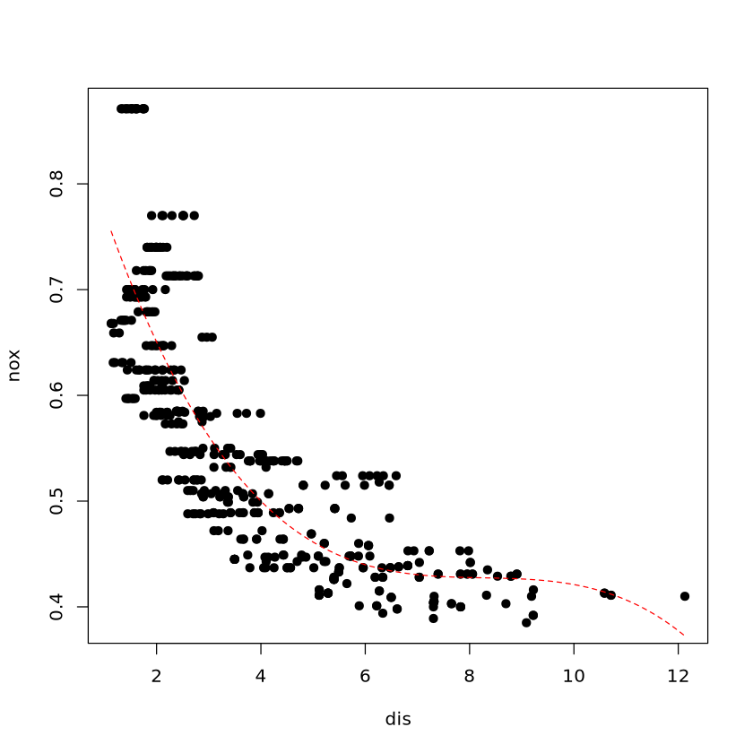

```r
# a

attach(Boston)
fit <- glm(nox ~ poly(dis, 3), data = Boston)
summary(fit)
plot(nox ~ dis, data = Boston,  pch = 19)
x <- seq(min(Boston$dis), max(Boston$dis), length.out = 1000)
lines(x, predict(fit, data.frame(dis = x)), col = "red", lty = 2)
```

1. 2.76856285896928

2. 2.03526186893526

3. 1.93410670717907

4. 1.93298132729859

5. 1.9152899610843

6. 1.87825729850816

7. 1.84948361458298

8. 1.83562968906769

9. 1.83333080449159

10. 1.83217112393135

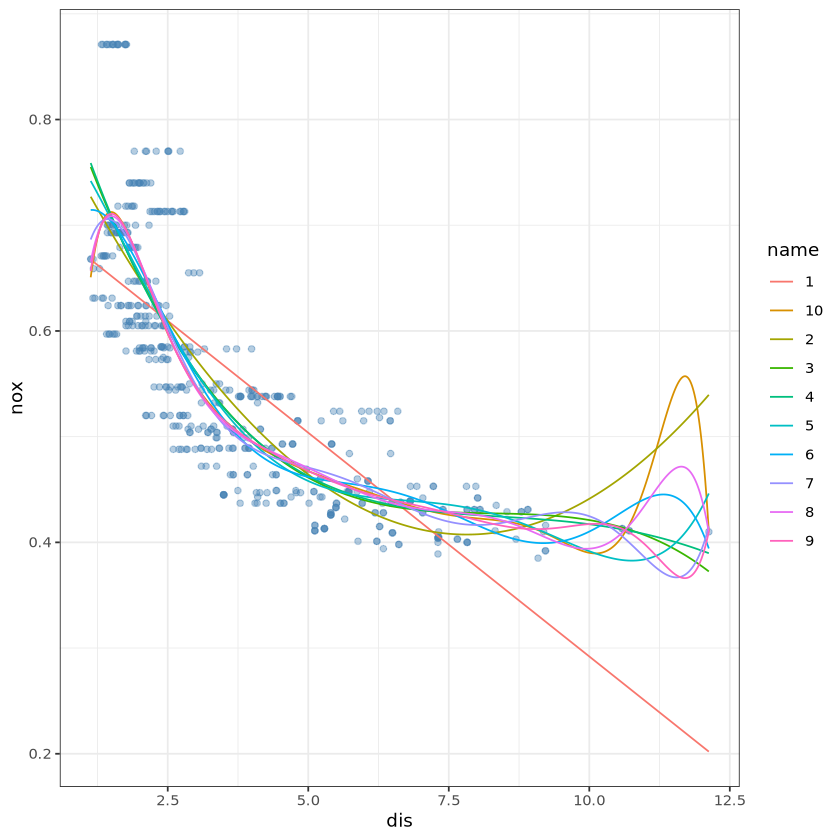

```r
# b
library(tidyverse)
fits <- lapply(1:10, function(i) glm(nox ~ poly(dis, i), data = Boston))

x <- seq(min(Boston$dis), max(Boston$dis), length.out = 1000)
pred <- data.frame(lapply(fits, function(fit) predict(fit, data.frame(dis = x))))
colnames(pred) <- 1:10
pred$x <- x
pred <- pivot_longer(pred, !x)
ggplot(Boston, aes(dis, nox)) +
  geom_point(color = alpha("steelblue", 0.4)) +
  geom_line(data = pred, aes(x, value, color = name)) +
  theme_bw()

# 残差平方和
do.call(anova, fits)[, 2]
```

```r
# c
library(boot)
res <- sapply(1:10, function(i) {
  fit <- glm(nox ~ poly(dis, i), data = Boston)
  cv.glm(Boston, fit, K = 10)$delta[1]
})
which.min(res)

# 交叉验证的最优度为3。较高的值往往会导致过拟合。
```

3

```
Call:
glm(formula = nox ~ bs(dis, df = 4), data = Boston)

Coefficients:
                 Estimate Std. Error t value Pr(>|t|)
(Intercept)       0.73447    0.01460  50.306  < 2e-16 ***
bs(dis, df = 4)1 -0.05810    0.02186  -2.658  0.00812 **
bs(dis, df = 4)2 -0.46356    0.02366 -19.596  < 2e-16 ***
bs(dis, df = 4)3 -0.19979    0.04311  -4.634 4.58e-06 ***
bs(dis, df = 4)4 -0.38881    0.04551  -8.544  < 2e-16 ***
---
Signif. codes:  0 ‘***’ 0.001 ‘**’ 0.01 ‘*’ 0.05 ‘.’ 0.1 ‘ ’ 1

(Dispersion parameter for gaussian family taken to be 0.003837874)

    Null deviance: 6.7810  on 505  degrees of freedom
Residual deviance: 1.9228  on 501  degrees of freedom
AIC: -1371.9

Number of Fisher Scoring iterations: 2
```

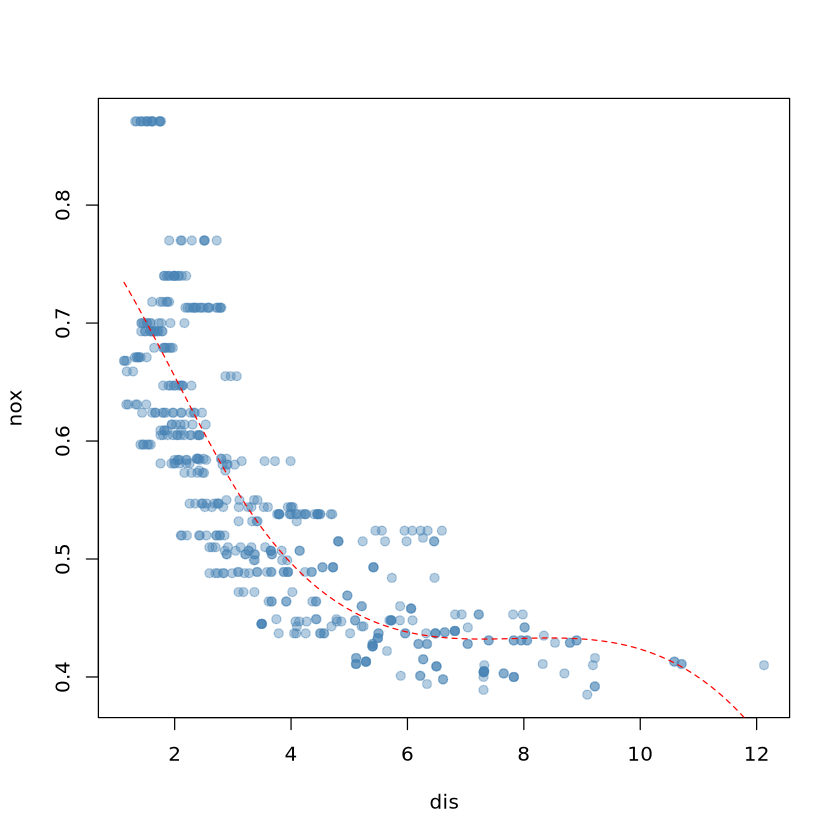

```r
# d
library(splines)
fit <- glm(nox ~ bs(dis, df = 4), data = Boston)
summary(fit)

plot(nox ~ dis, data = Boston, col = alpha("steelblue", 0.4), pch = 19)
x <- seq(min(Boston$dis), max(Boston$dis), length.out = 1000)
lines(x, predict(fit, data.frame(dis = x)), col = "red", lty = 2)

# 结点knot是根据数据的分位数来选择的。
```

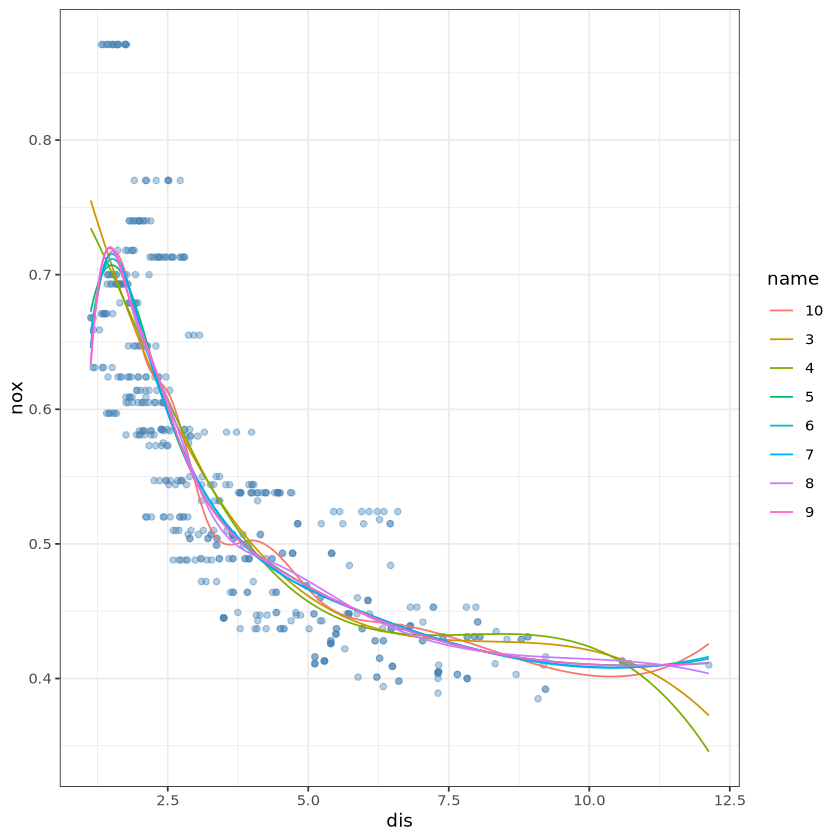

```r
# e

fits <- lapply(3:10, function(i) {
  glm(nox ~ bs(dis, df = i), data = Boston)
})

x <- seq(min(Boston$dis), max(Boston$dis), length.out = 1000)
pred <- data.frame(lapply(fits, function(fit) predict(fit, data.frame(dis = x))))
colnames(pred) <- 3:10
pred$x <- x
pred <- pivot_longer(pred, !x)
ggplot(Boston, aes(dis, nox)) +
  geom_point(color = alpha("steelblue", 0.4)) +
  geom_line(data = pred, aes(x, value, color = name)) +
  theme_bw()

# 在自由度较高的情况下，样条曲线会过度拟合数据（特别是在预测变量分布的极端末端）
```